# Predicting the Quality of Wines

Jae-Ho Lee

# Abstract

> Statistical learning techniques were utilized in predicting the quality of wines given their various properties and attributes. A data set that represents more of the lower-end and higher-end of wine quality should be included to yield a more effective model.

# Introduction

Wine has a reputation for being a beverage of wide range and depth of taste, and such public perception of the beverage allows it to distinguish itself from other alcoholic beverages. While this image of the beverage may arouse pride in wine-buffs, it may also serve as deterrent for those interested in entering the world of wine. The rise of interest in wine led to a demand for the numeric rating of the quality of wine, which was popularized in ithe U.S. by Robert Parker in the 1970s [^1]. Wine ratings lower the barrier to wine tasting help amateur wine-tasters more easily discover “good wine.”

The rating of wine is usually undergone by aggregating the rating of one or more wine critiques. The following analysis performs statistical learning techniques on various physiochemical attributes of wines in order to predict the quality of wines. While the random forest model best performed in predicting wine quality, additional measures in the analysis could be made for improvement.

# Methods

## Models

5-fold cross-validation was used as the validation measure for the trained models.

1. Random Forest

```r
rf_mod = train(quality_cat ~ . , wine_trn,
                 method = "ranger",
                 metric = "Accuracy",
                 trControl = cv)
```

2. Naive Bayes

```r
nb_mod = train(quality_cat ~ . , wine_trn,
                  method = "nb",
                  metric = "Accuracy",
                  trControl = cv)
```

3. Support Vector Machine

```r
svm_mod = train(quality_cat ~ . , wine_trn,
                method = "lssvmRadial",
                metric = "Accuracy",
                trControl = cv,
                verbose = FALSE)
```

4. Multinomial Regression

```r
multinom_mod = train(quality_cat ~ . , wine_trn,
                method = "multinom",
                metric = "Accuracy",
                trControl = cv,
                trace = FALSE)
```

# Results

Accuracy was measured in order to assess the effectiveness of the models.

5-Fold Cross-Validation

| Model | Accuracy |
| --- | --- |
| Random Forest | 0.6749 |
| Naive Bayes | 0.4923 |
| Support Vector Machine | 0.5621 |
| Multinomial Regression | 0.5441 |

# Discussion

**Random Forest** Accuracy

| Test Accuracy |
| --- |
| 0.6936 |

Test Confusion Matrix

|  | 3 | 4 | 5 | 6 | 7 | 8 | 9 | Sum |
| --- | --- | --- | --- | --- | --- | --- | --- | --- |
| 3 | 0 | 0 | 0 | 0 | 0 | 0 | 0 | 0 |
| 4 | 0 | 6 | 1 | 1 | 0 | 0 | 0 | 8 |
| 5 | 1 | 25 | 306 | 74 | 5 | 0 | 0 | 411 |
| 6 | 1 | 15 | 130 | 461 | 100 | 15 | 1 | 723 |
| 7 | 0 | 0 | 2 | 17 | 114 | 10 | 0 | 143 |
| 8 | 0 | 0 | 0 | 0 | 0 | 14 | 0 | 14 |
| 9 | 0 | 0 | 0 | 0 | 0 | 0 | 0 | 0 |
| Sum | 2 | 46 | 439 | 553 | 219 | 39 | 1 | 1299 |

# Appendix

## Data Dictionary

- `fixed acidity`
- `volatile acidity`
- `citric acid`
- `residual sugar`
- `chlorides`
- `free sulfur dioxide`
- `total sulfur dioxide`
- `density`
- `pH`
- `sulphates`
- `alcohol`
- `quality`
  - Score between `0` and `10` based on sensor reading
- `color`
  - `White` or `Red`

## Exploratory Data Anlysis

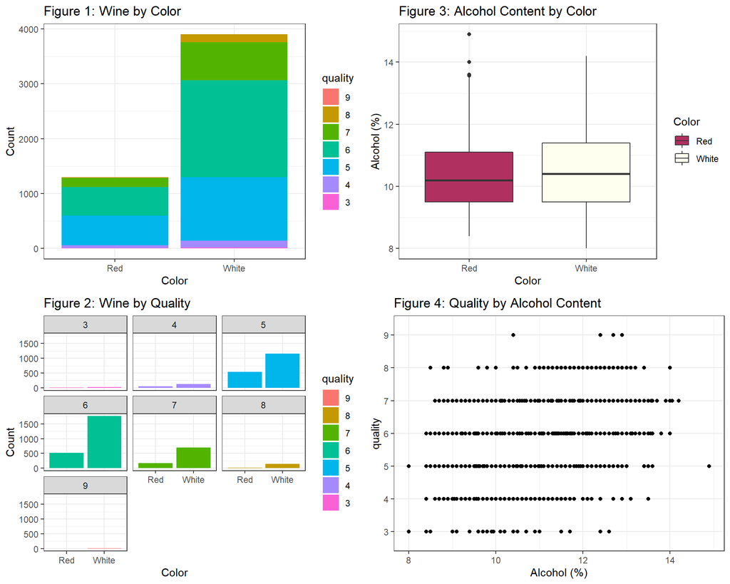

[^1]: [Wine Rating](https://en.wikipedia.org/wiki/Wine_rating)
[^2]: [Wine Quality Data Set](https://archive.ics.uci.edu/ml/datasets/Wine+Quality)